# Simulating exponential survival times

We’re going to try simulating survival data with exponentially distributed failure times. Bunch of ways to do this:

- Using the `Distributions.jl` package to sample exponential random variates.
- Using the inverse CDF method, i.e., sampling Unif(0,1) variates and using the survival function (Crowther and Lambert).
- By integrating an exponential density to get the exponential CDF and then appealing to the previous method.
- Other algorithms, e.g., uniformization, importance/rejection sampling, MCMC, etc.

notes from 25th May 2021:

### Environment

Julia can be run from JUPYTER notebooks (‘JU’)

Install JULIA (https://julialang.org/downloads/) and install packages for JULIA JUPYTER: https://datatofish.com/add-julia-to-jupyter/

I ran this from the Julia REPL but there are many other options… import Pkg using Pkg Pkg.add(“IJulia”)

Julia can be run from Rstudio in Rnotebook https://github.com/Non-Contradiction/JuliaCall

In Rstudio:

```r
#install.packages("JuliaCall")
library(JuliaCall)
julia_setup(JULIA_HOME = 'C:/Users/hartwickma/AppData/Local/Programs/Julia-1.6.1/bin/') #specific to where your Julia installed
```

```
## Julia version 1.6.1 at location C:\Users\HARTWI~1\AppData\Local\Programs\JULIA-~1.1\bin will be used.
```

```
## Loading setup script for JuliaCall...
```

```
## Finish loading setup script for JuliaCall.
```

```r
julia <- julia_setup()
library(tidyverse)
```

```r
#plot theme
mytheme <- theme(
  panel.border = element_blank(),
  panel.grid.major = element_line(color = 'grey60', linetype = 'dashed',
                                  size = 0.5),
  panel.grid.minor = element_blank(),
  panel.background = element_rect(colour = "white", fill = "white"),
  legend.position = "right", axis.line = element_line(colour = "white"),
  legend.key = element_rect(fill = NA),
  legend.text.align = 0,
  text = element_text(color = 'grey5'),
  axis.text.x = element_text(colour = "grey5", size = 10),
  axis.text.y = element_text(colour = "grey5", size = 10,),
  axis.ticks = element_line(colour = "grey5"),
  title = element_text(colour = 'grey5', size = 10))
```

Now you’re ready to run Julia from JUPYTER notebook or Rnotebook (Rmarkdown works too…different discussion)

Visual studio documentation: ?

### Rstudio Rnotebook

quick Rnotebook shortcuts: ctrl + alt + I to insert code chunks ctrl + shitft + enter to execute code chunk

test that julia can be found in rstudio

```julia
println("Hello world (in Julia from an Rnotebook...)")
```

```
## Hello world (in Julia from an Rnotebook...)
```

#### set up environment to work with distributions and plotting

```julia
import Pkg
Pkg.add("Distributions")
Pkg.add("Random")
Pkg.add("Plots")
Pkg.add("GR")
Pkg.add("DataFrames")
```

#### background

In R: p for “probability”, the cumulative distribution function (c. d. f.) q for “quantile”, the inverse c. d. f. d for “density”, the density function (p. f. or p. d. f.) r for “random”, a random variable having the specified distribution

Distribution Functions Beta pbeta qbeta dbeta rbeta Binomial pbinom qbinom dbinom rbinom Cauchy pcauchy qcauchy dcauchy rcauchy Chi-Square pchisq qchisq dchisq rchisq Exponential pexp qexp dexp rexp F pf qf df rf Gamma pgamma qgamma dgamma rgamma Geometric pgeom qgeom dgeom rgeom Hypergeometric phyper qhyper dhyper rhyper Logistic plogis qlogis dlogis rlogis Log Normal plnorm qlnorm dlnorm rlnorm Negative Binomial pnbinom qnbinom dnbinom rnbinom Normal pnorm qnorm dnorm rnorm Poisson ppois qpois dpois rpois Student t pt qt dt rt Studentized Range ptukey qtukey dtukey rtukey Uniform punif qunif dunif runif Weibull pweibull qweibull dweibull rweibull Wilcoxon Rank Sum Statistic pwilcox qwilcox dwilcox rwilcox Wilcoxon Signed Rank Statistic psignrank qsignrank dsignrank rsignrank

generate n random numbers from a normal distribution with given mean & st. dev. http://uc-r.github.io/generating_random_numbers/#normal rnorm(n, mean = 0, sd = 1)

generate CDF probabilities for value(s) in vector q pnorm(q, mean = 0, sd = 1, lower.tail = TRUE, log.p = FALSE)

generate quantile for probabilities in vector p (inverse cdf) qnorm(p, mean = 0, sd = 1, lower.tail = TRUE, log.p = FALSE)

generate density function probabilites for value(s) in vector x dnorm(x, mean = 0, sd = 1)

```r
set.seed(600)
x <- rnorm(100, mean = 0, sd = 1)
x
```

```
##   [1] -1.120141510  0.198274128  0.645165805 -0.151451864 -0.018417394
##   [6]  0.017708063 -1.218327185 -1.652126382  0.038526642 -1.372054366
##  [11] -0.065281901 -0.284743988 -2.247559312 -0.297285342  0.387511421
##  [16]  0.397237534 -1.064894960  1.587789003  0.691938248 -0.135687193
##  [21] -0.273152000  1.884521970 -0.062745485  0.637006416 -0.855799426
##  [26] -0.148366234  0.451577585  0.193132250  0.267692599  1.516907014
##  [31] -0.645465827  0.924508009 -1.841537457  0.427956522  0.842575737
##  [36]  0.445836947  0.174691590 -0.669760670  0.147109885  0.659786561
##  [41] -1.094945595  2.823887433  1.389127785  0.173888546 -1.521796508
##  [46] -0.374253915  0.620091353  1.407577293  0.617263315 -0.334741103
##  [51] -0.333161794 -0.109145411 -0.141716134 -1.398226699  1.045304389
##  [56] -0.555712303  0.813097415 -1.416854235 -1.027853457  0.363124840
##  [61]  1.222342162  1.668050013  0.520631295  0.876535019 -0.213783260
##  [66] -2.540996155 -1.223807117  0.428402766  1.010294190  0.882948620
##  [71] -0.587747915  0.666162841  0.263254546 -0.296941435 -1.005047506
##  [76]  0.049005348 -1.123757934 -2.054917462  1.033270911  0.384709551
##  [81] -0.093416767  0.398129493  0.685987491  0.249878194 -0.732262952
##  [86]  1.672007046  1.413112789 -1.059201777  0.686760592 -0.714060160
##  [91] -0.671134715 -0.078630143  0.299528064  0.578238729 -0.008601567
##  [96]  2.684556868  2.121223758  0.656988181 -0.467340614 -1.190910789
```

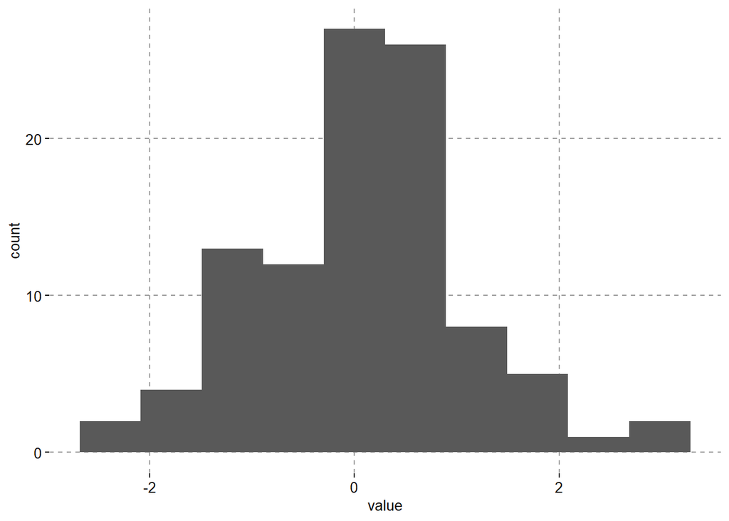

```r
x %>%
  as_tibble() %>%
  ggplot(., aes(value)) +
  geom_histogram(bins = 10) +
  mytheme
```

```r
p_x <- pnorm(x, mean = 0, sd = 1)
t <- cbind(X = x, cdf = p_x)
head(t)
```

```
##                X       cdf
## [1,] -1.12014151 0.1313267
## [2,]  0.19827413 0.5785847
## [3,]  0.64516581 0.7405901
## [4,] -0.15145186 0.4398096
## [5,] -0.01841739 0.4926529
## [6,]  0.01770806 0.5070641
```

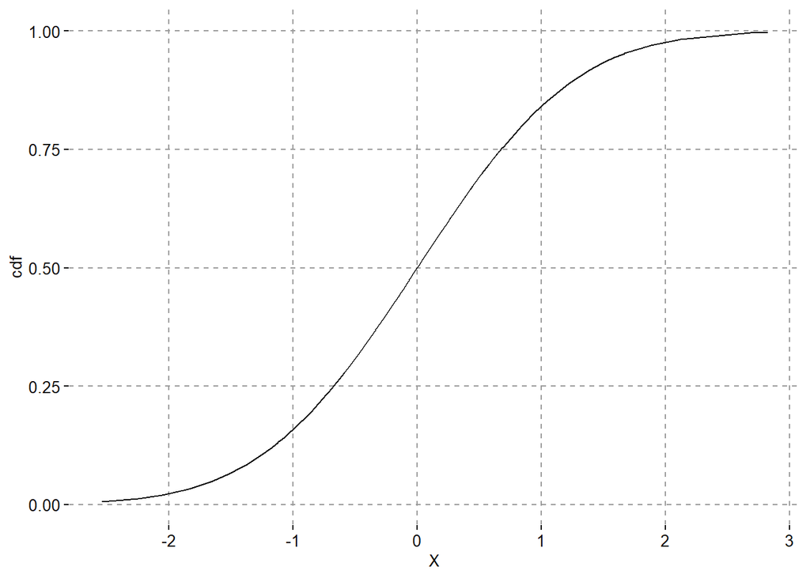

```r
t %>%
  as_tibble() %>%
  ggplot(., aes(x=X, y = cdf)) +
  geom_line() +
  mytheme
```

```r
# usage: the probability of a value given mean and sd
dnorm(27.4, mean=0, sd=1)
```

```
## [1] 3.762248e-164
```

```r
# or
d_x <- dnorm(x, mean = 0, sd = 1)
t <- cbind(t, pdf = d_x)
head(t)
```

```
##                X       cdf       pdf
## [1,] -1.12014151 0.1313267 0.2130354
## [2,]  0.19827413 0.5785847 0.3911771
## [3,]  0.64516581 0.7405901 0.3239850
## [4,] -0.15145186 0.4398096 0.3943930
## [5,] -0.01841739 0.4926529 0.3988746
## [6,]  0.01770806 0.5070641 0.3988797
```